[figure not shown]

Uppföljning Dalastrategin

# Uppföljning Dalastrategin

Rapporten är skapad av Samhällsanalys, Region Dalarna  
Senast uppdaterad: 2026-03-10

# Introduktion

Dalarna står tillsammans med övriga Sverige, Europa och världen inför stora samhällsutmaningar. För att skapa en hållbar framtid för Dalarna antog Regionfullmäktige i juni 2021 en ny regional utvecklingsstrategi (reviderad och beslutad 2026-02-16), [“Dalastrategin - Tillsammans för ett hållbart Dalarna”](https://www.regiondalarna.se/globalassets/regional-utveckling/dalastrategin-2030-tillsammans-for-ett-hallbart-dalarna-dec.pdf).

Strategin är ett stöd och en språngbräda i arbetet med att rusta Dalarna för att möta framtidens utmaningar och göra dem till möjligheter. Målsättningarna för Dalarna sammanfattas i tre målområden som kopplar an till de olika dimensionerna av hållbarhet - miljömässig, ekonomisk och social hållbarhet:

- ett klimatsmart Dalarna
- ett sammanhållet Dalarna
- ett konkurrenskraftigt Dalarna

Att ställa om för att skapa en hållbar framtid är en utmaning som berör alla delar av samhället, från global till lokal nivå och inom alla sektorer. Omställningen innebär att flytta fokus från kortsiktiga resultat till arbetssätt som säkrar naturresurserna långsiktigt så att människor kan leva gott på dess avkastning också i många generationer. Rent vatten, ren luft, biologisk mångfald och andra ekosystem är grundläggande värden för människor och samhällen, och att vårda människor och människors hälsa, kunskap och bildning är grunden till att skapa långsiktig ekonomisk nytta och ekonomisk trygghet.

Den här rapporten är en del av den årliga uppföljningen av Dalarnas utveckling och beskriver läget i Dalarna på vägen till en hållbar framtid.

Rapporten är uppdelad efter strategins målområde; klimatsmart, konkurrenskraftigt och sammanhållet. Varje målområde är sedan uppdelat i tre avsnitt, som vart och ett är tänkta att fånga naturresurserna, samspel och beteendemönster samt ekonomiska värden. För klimatsmart Dalarna är exempelvis vind och vatten naturresurser, byten från bensinbilar till elbilar en del av beteendet och mängden regional produktion av miljövänlig electricitet ekonomiska värden. Inom konkurrenskraftigt är arbetskraft och kompetens naturresurser, ett gott företagsklimat beteeendet, och företagens produktion ekonomiska värden, och i sammanhållet är befolkningens hälsa och trygghet naturresurser, befolkningens görande, samhällsengagemang beteenden samt fördelningen av ekonomiska värden mellan människor en del av den ekonomiska delen av sammanhållet.

# 1 Ett klimatsmart Dalarna

Ett klimatsmart Dalarna är ett resurseffektivt Dalarna utan klimatpåverkande utsläpp. Resande sker på ett enkelt och miljömässigt hållbart sätt. I ett klimatsmart Dalarna är samhällets robusthet och resiliens vid klimatförändringar god.

Den miljömässiga dimensionen för en hållbar regional utveckling handlar bland annat om att säkerställa att ekosystemen bibehålls och vårdas så att de fortsätter att leverera de tjänster som människor och samhällen är beroende av.

Dalarna är rikt på naturresurser och om de brukas rätt ger de mångfalt tillbaka, därför följs bland annat hur resurser som vatten och vind, skog och jordbruksmark används. I Dalarna utgörs samtidigt en stor del av näringslivet av tillverkande industri som förbrukar relativt sett stora mängder energi och driver därigenom upp mängden energi förbrukad per invånare.

Det är en viktig avvägning mellan nytta och miljöpåverkan, att bedöma huruvida Dalarnas företag har det produktionssätt som har den minsta miljöpåverkan i global jämförelse och därmed motiv till att just företagen i Dalarna ska bedriva denna produktion.

## 1.1 Tillståndet i Dalarnas miljö och natur

Sammanfattande resultat…

Vatten ➡  
Luft ⬆  
Skog och mark ⬇  
Biologisk mångfald ⬇

Länsstyrelserna i Sverige har i uppdrag att följa upp tillståndet i miljön i respektive län. För Dalarna finns redovisningen [“här”](https://www.rus.se/regional-arlig-uppfoljning/dalarnas-lan/#generation), för den som vill fördjupa sig ytterligare.

### Vatten

Tillgången till grundvatten av god kvalitet är god och flera vatten som tidigare varit försurade har återhämtat sig. Samtidigt fortsätter tillåtna men miljöfarliga ämnen och nya ämnen med okända effekter släppas ut i miljön. Övergödningsproblemen är störst i jordbruksområden i de sydöstra delarna av länet.

Dalarna har god tillgång till grundvatten av god kvalitet ur ett regionalt perspektiv. Arbetet med statusklassificering 2018-2019 visar dock att ca 40 av Dalarnas 277 grundvattenförekomster riskerar att inte nå god kemisk status till år 2027. Det atmosfäriska nedfallet har avtagit och flera vatten som tidigare varit försurade har återhämtat sig. Kalkningen har kunnat minskas i delar av Dalarnas län. Hundratals ämnen påträffas i Dalarnas ytvatten vilket återspeglar den stora kemikalieanvändningen i samhället och industrin. Halter av förbjudna ämnen i miljön sjunker, samtidigt släpps tillåtna miljöfarliga ämnen och nya ämnen med okända effekter ut i miljön. Övergödningsproblemen är störst i jordbruksområden i de sydöstra delarna av länet. Åtgärdsarbetet har ökat på senare år, men det är inte tillräckligt för att målet ska kunna nås. Det tar också tid innan minskade utsläpp ger effekt i de vatten som är övergödda, bland annat eftersom den naturliga återhämtningen är långsam. Ännu märks inga tydliga förbättringar i miljön på regional nivå.

Vattendragen i länet är kraftigt påverkade av fysiska ingrepp som rätning och rensningar, samt av vandringshinder och flödesreglering. Med dagens åtgärdstakt nås målet Levande sjöar och vattendrag om ungefär 200 år. Kunskapsbristen för kulturmiljövärden är stor även om förbättringar skett under senare år. Fler sjöar och vattendrag behöver skyddas genom inrättande av områdesskydd.

Flera försurade vatten återhämtar sig och kalkningen har kunnat minskas i delar av länet. Minskande anslag leder till att kalkning behövt avslutas för sjöar och vattendrag med fortsatt behov av kalkning.

Dalarnas grundvatten håller en god kvalitet men för vissa grundvattenförekomster finns det en risk att de ej når god kemisk status till 2027. Återhämtningstiden för övergödda vatten är lång och ännu märks inga tydliga förbättringar i miljön. Flertalet vattendragsrestaureringar pågår men åtgärdsbehovet är stort.

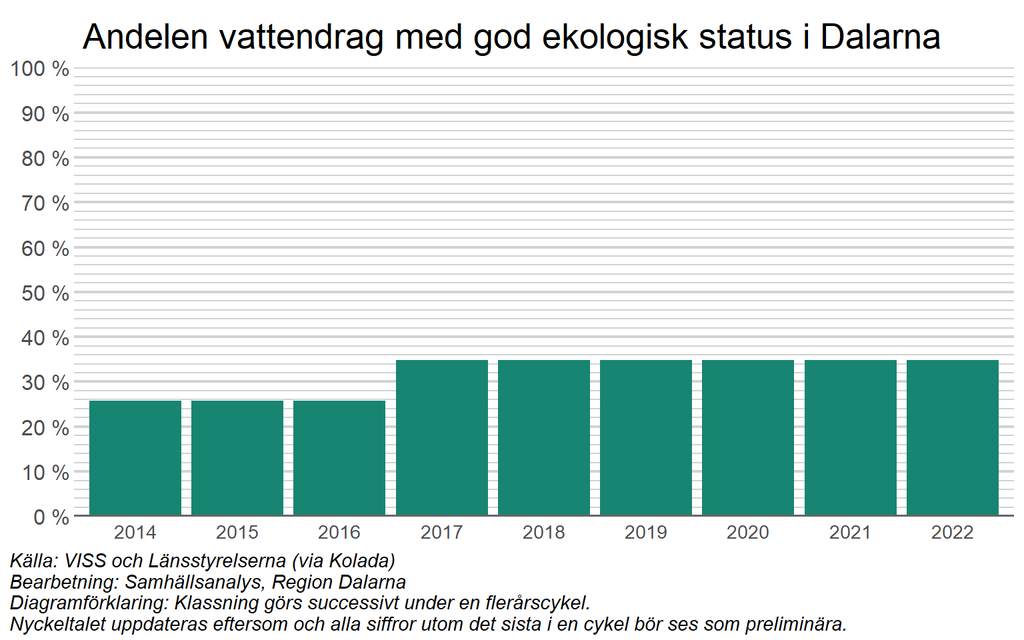

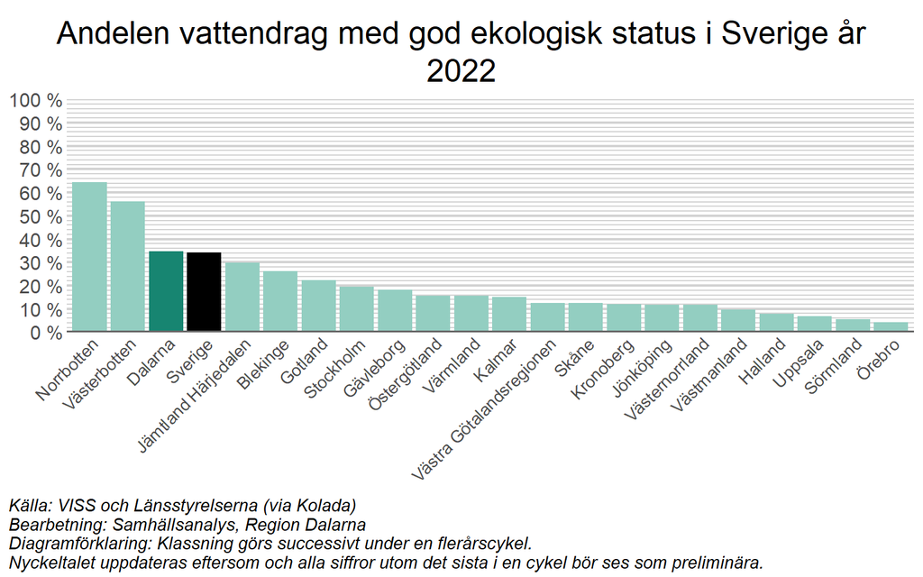

### Luft

Luftkvaliteten är generellt god i Dalarna men försämrad i tätorter på grund av utsläpp från trafik, industri, uppvärmning av bostäder och småskalig vedeldning. Lokalt kan det periodvis finnas problem med föroreningar kopplat till veteranbilar.

### Skog och mark

**Skogsmark** I Dalarna genomförs många insatser för förbättrad miljöhänsyn och ökad kunskap om skogens natur- och kulturvärden. Viktiga strukturer, som död ved, ökar men saknas fortfararande i tillräcklig mängd. Bestånd med naturvärden och lång skoglig kontinuitet avverkas. Antalet hotade arter och skador på forn- och kulturlämningar är fortsatt på en hög nivå. För att nå miljömålet behöver sektorns ansvar förtydligas och insatser öka för inventering, skydd, naturvårdande skötsel och större variation i skogsbruket.

En förutsättning för bibehållen biologisk mångfald och bevarade kulturmiljövärden i odlingslandskapet är att det finns hållbara och bärkraftiga jordbruksföretag i länet och betande djur i landskapet.

Antal betesdjur har minskat stadigt i Dalarnas län sedan 1980-talet, liksom antalet jordbruksföretag och arealen brukad jordbruksmark. Med färre betande djur och marker som inte längre hävdas försämras förutsättningarna för att bibehålla ett rikt odlingslandskap i länet.

Klimatförändringar påverkar fjällen och dess ekosystemprocesser allt mer. Låglandsarter sprider sig in i fjällen och invasiva arter har spridit sig in i fjällområdet. Flera sjöar är försurade och kalkas för att gynna växt- och djurlivet. Inventering av fjällnära skogar har visat på höga biologiska värden, varför skydd av de fjällnära skogarna är av stor vikt. Fjällskogens kulturlämningar är däremot dåligt kända och sällan undersökta. Exploaterings- och besökstrycket ökar med markslitage, nedskräpning och störning av ren som följd.

År 2018 beslutade dåvarande regering om Sveriges första nationella skogsprogram med fokus på skogsbrukets roll för en hållbar utveckling. I Dalastrategin omnämns skogsbruket som en av länets viktigare näringar. Skogsbruket påverkar och påverkas av klimatförändringarna, och därför behöver skötsel och brukande anpassas utifrån rådande kunskap om vad som har minst miljöpåverkan.

Dalarnas yta utgörs till 79 procent av skog vilket gör Dalarna till det femte mest skogstäta länet i landet [(SCB)](https://www.scb.se/hitta-statistik/sverige-i-siffror/miljo/marken-i-sverige/). All skogsmark är inte produktiv (ex. myrar och bergsytor etc. som producerar mindre än en kubikmeter virke per hektar och år). Dessa områden utgör 11,3 procent av skogsmarken, varav ca 1,5 procentenheter är formellt skyddad. Skogsbruket i Dalarna brukas nästan enbart med konventionella metoder, ca 78 procent av skogsmarken brukas konventionellt [(SCB)](https://www.statistikdatabasen.scb.se/pxweb/sv/ssd/START__MI__MI0605/SkyddSkogFrivillig/table/tableViewLayout1/).

Skyddad produktiv skog, tillsammans med frivilliga avsättningar av produktiv skog utgör andelen som brukas på ett hållbart sätt. I diagrammen nedan redovisas hur andelen skyddad produktiv skogsmark i Dalarnas län utvecklats mellan 2018 och 2024. Arealen skyddad skogsmark i länet har ökat med knappt 7 procent över tidsperioden, från 116 500 hektar år 124 200 hektar år 2024.

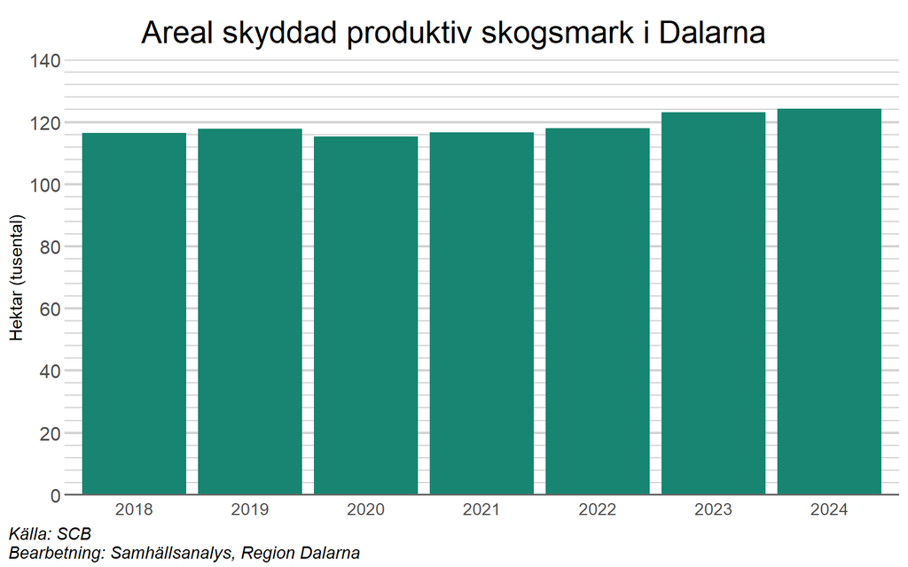

Drygt 6 procent av den produktiva skogsmarken i Dalarnas län var skyddad år 2024, vilket är en något större andel än 2018. Det betyder att den totala arealen produktiv skogsmark har ökat något under perioden.

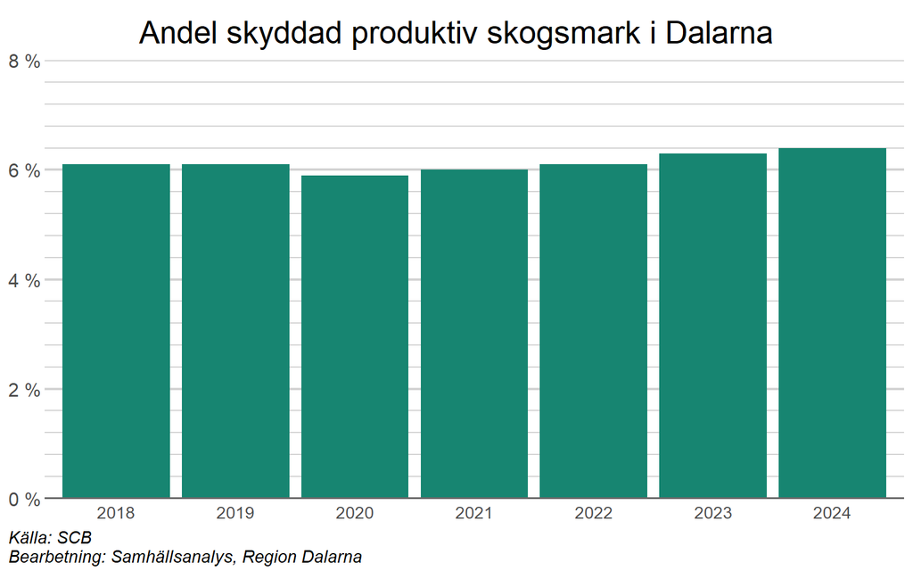

### Biologisk mångfald

**Betesmark och slåtteräng**

Biologisk mångfald och väl fungerande ekosystem är en förutsättning för allt liv på jorden, att vårda dem ger goda livsmiljöer för både Dalarnas invånare och för Dalarnas näringsliv. Den gröna infrastrukturen är ekologiskt funktionella nätverk av livsmiljöer och naturområden som utformas, brukas och förvaltas så att den biologiska mångfalden bevaras och därmed främjar för samhället så centrala ekosystemtjänster som exempelvis vattenrening och livskraftiga jordbruksmarker, etc. Samhället har allt att vinna på ett hållbart bruk av ekosystemen och att förvalta ett mångfunktionellt landskap där natur- och kulturvärden tillvaratas.

Betesmark tillsammans med åkermark utgör jordbruksmark. Åkermarken kan brukas för djurfoder och livsmedel, medan betesmarken och betande djur i hög grad bidrar till att upprätthålla artrikedomen. En delmängd av betesmarken är slåtterängar, som har särskilt höga biologiska värden.

Det bedrivs ett gediget arbete för att gynna arter, skapa livsmiljöer och förbättra grönstruktur i Dalarna. Trots det är 1 396 av länets arter rödlistade och vissa nära att dö ut på grund av markanvändning och global uppvärmning. Klimatförändring kan ha bidragit till lokala utdöenden av Dalarnas landskapsfjäril violett guldvinge de senaste årtiondena, 2025 fanns den bara på en lokal. Invasiva främmande arter ökar trots att många bekämpar dem. Havsörnen tycks ha haft sämre framgång 2023-2025 än 2021-2022.

I diagrammet nedan redovisas hur arealen betesmark i Dalarnas län har utvecklats mellan 2011 och 2024. I diagrammet är den totala arealen betesmark uppdelad på slåtteräng och alla annan betesmark, benämnd övrig betesmark. Den totala arealen betesmark har under denna period minskat med ungefär 15 procent, från 11 908 till 10 167 hektar. Efter en tydlig minskning mellan 2022 och 2023, ökade arealen betesmark återigen år 2024.

Slåtteräng är en delmängd av betesmarken som har särskilt höga biologiska värden och därmed särskilt stor betydelse för biologisk mångfald. I Dalarna har andelen slåtteräng ökat från 1,2 procent av betesmarken år 2011 till 2 procent av betesmarken år 2024.

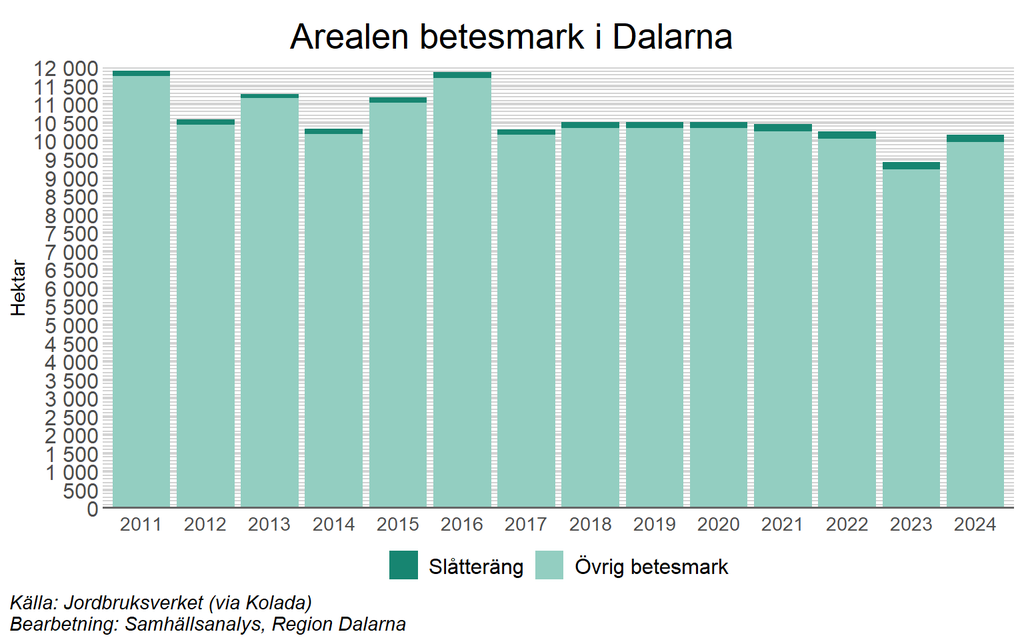

Flera insatser görs i samhället som bedöms gynna tillståndet för den biologiska mångfalden. Genom våtmarkssatsningen restaureras och anläggs många våtmarker i länet. Takten i arbetet har goda förutsättningar att öka i och med klimatarbetet och ett ökande fokus på naturtypsrestaurering. Utvecklingen påverkas däremot negativt av den långsamma igenväxning som sker generellt på myrar samt exploatering i form av dikning vid vägar och järnvägar.

Renbetesmarker Klimatförändringar påverkar fjällen och dess ekosystemprocesser allt mer. Låglandsarter sprider sig in i fjällen och invasiva arter har spridit sig in i fjällområdet. Flera sjöar är försurade och kalkas för att gynna växt- och djurlivet. Inventering av fjällnära skogar har visat på höga biologiska värden, varför skydd av de fjällnära skogarna är av stor vikt. Fjällskogens kulturlämningar är däremot dåligt kända och sällan undersökta. Exploaterings- och besökstrycket ökar med markslitage, nedskräpning och störning av ren som följd.

## 1.2 Beteenden som påverkar miljö och resursförbrukning i Dalarna

Förutsättningar för att ändra beteenden Utfall av förändrade beteenden

Utsläpp av växthusgaser ➡

Kollektivt resande ➡

Övergång till elbilar ⬆

Insamlat avfall ⬇

Kommunala klimatanpassningsplaner ⬇

Under flikarna hittar den som önskar fördjupad information om varje variabel.

### Utsläpp

År 2017 antog Sverige ett långsiktigt nationellt mål om att landet ska vara klimatneutralt år 2045. Detta innebär en minskning av växthusgasutsläpp med minst 85 procent inom landets gränser i jämförelse med utsläppen år 1990. Målet innebär i princip att alla sektorer och verksamheter behöver vara fossilfria år 2045. Sveriges nationella mål är i linje med det europeiska målet om ett klimatneutralt EU till år 2050 och det internationella Parisavtalet som innebär att jordens länder strävar efter att ökningen av den globala genomsnittstemperaturen inte blir mer än 1,5°C till år 2050 i förhållande till den förindustriella nivån, samt att den i vilket fall inte överstiger 2°C.

De klimatpåverkande växthusgaserna innefattar fler ämnen än koldioxid. Ett exempel är metangas som även är betydligt skadligare per enhet än koldioxid (1 ton metangas motsvarar utsläpp av ca 28 ton koldioxid). För att utsläppen som sker i Dalarna ska vara jämförbara med andra regioners utsläpp omsätts därför samtliga gasers utsläpp till så kallade koldioxidekvivalenter, det vill säga den mängd som varje ämne släpper ut omräknat i termer av koldioxid.

I Dalarna har utvecklingen gått i positiv riktning med minskande utsläpp av växthusgaser under de senaste decennierna. Det är industri- och transportsektorerna som står för den volymmässigt största minskningen samtidigt som dessa sektorer, i likhet med övriga Sverige, står för den största andelen utsläpp av växthusgaser totalt sett i länet. Diagrammet visar även att utsläppen minskade tydligt under pandemiåret 2020, rimligtvis för att produktionstakten saktade in, men ökade år 2021. Under år 2022 minskade utsläppen återigen och var på den lägsta nivån sedan åtminstone 2005. Ska utsläppsmålen uppnås krävs dock en betydligt snabbare minskningstakt.

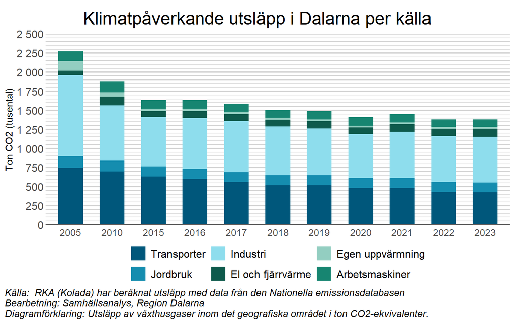

Sett till utsläpp per person ligger Dalarna högre än riksgenomsnittet, trots en minskning från knappt 8,3 ton/invånare år 1990 till ungefär 5 ton/invånare år 2023. För att uppnå målet om klimatneutralitet 2045, skulle utsläppen behöva minska till ca 1,25 ton/invånare år 2045, vilket innebär en minskning om ungefär 6 procent årligen mellan 2023 och 2045. Som jämförelse minskade utsläppen per person i Dalarna med ungefär 3 procent per år mellan 2015 och 2023. Även om vi ser en utveckling i rätt riktning kommer det således att krävas en ännu snabbare minskningstakt för att uppnå våra ambitioner i Dalastrategin och bli klimatneutrala till år 2045 i enlighet med den nationella målsättningen.

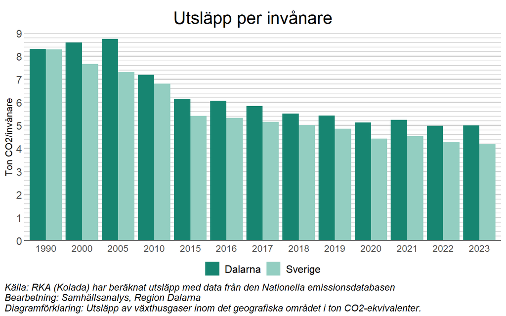

### Kollektivt resande

Den utsträckta och relativt glesbefolkade geografin i Dalarna är utmaningar i arbetet med att skapa en hållbar transportinfrastruktur. För att transportsektorn ska nå klimat- och energimålen krävs kraftfull teknisk utveckling i kombination med beteendeförändringar så som minskad konsumtion av varor vars transporter orsakar höga utsläpp, ökad samåkning och minskat resande totalt sett. Kollektivt resande spelar en central roll för utvecklandet av en klimatsmart och resurseffektiv, men också mer jämlik, mobilitet. Kollektivtrafik bidrar både till miljönytta och samhällsekonomisk effektivitet men är också förenat med höga kostnader. För att klara omställningen krävs mod att ställa olika kostnader mot varandra. För att det kollektiva resandet ska öka behöver den traditionella kollektivtrafiken sannolikt kompletteras med nya mobilitetslösningar och tjänster, särskilt för länets mest glesbefolkade områden.

Diagrammen redovisar indikatorer för kollektivt resande i Dalarna: Kollektivtrafiksresor per invånare samt marknadsandel för kollektivtrafik i länet. För antal resor per invånare syns att det kollektiva resandet har minskat avsevärt i Dalarna, från 46 resor per person och år 2003 till 32 resor år 2024. Nedgången kan delvis förklaras av pandemin - det sker en tydlig minskning mellan 2019 och 2020 - men även mellan 2012 och 2013 minskade antalet resor per invånare avsevärt i Dalarna. I en nationell jämförelse år 2024 framgår att det i glesbygdslänen i Sverige som mest görs runt 60 resor per person, medan det görs betydligt fler i storstadsregionerna, så som Skåne med i snitt 122 resor per person och år. I Stockholm där flest resor sker, görs 306 resor per person och år. I jämförelse med Sveriges övriga län görs näst minst antal resor med kollektivtrafik per invånare i Dalarna. Bara på Gotland görs färre resor (Kolada).

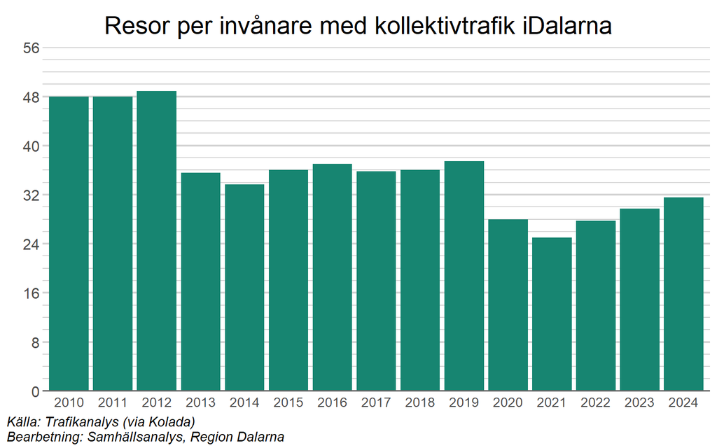

Marknadsandelen för kollektivtrafik beräknas som andelen resor med kollektivtrafik (linjelagd buss, spårvagn, tunnelbana, pendeltåg, tåg och båt) och taxi av det totala antalet resor, dvs kollektivtrafik, taxi, bil (förare och passagerare) samt moped/MC. Efter ett antal år av ökande marknadsandel för kollektivtrafiken bröts uppgången år 2020 av en förmodad pandemieffekt. Nedgången fortsatte år 2021 när marknadsandelen för kollektivtrafik bara var 6 procent. Därefter ökade marknadsandelen under ett par år, innan den minskade igen år 2024. Sett över hela tidsperioden 2010 till 2024 har marknadsandelen för kollektivtrafik minskat med 1 procentenhet, från 10 procent år 2010 till 9 procent år 2024.

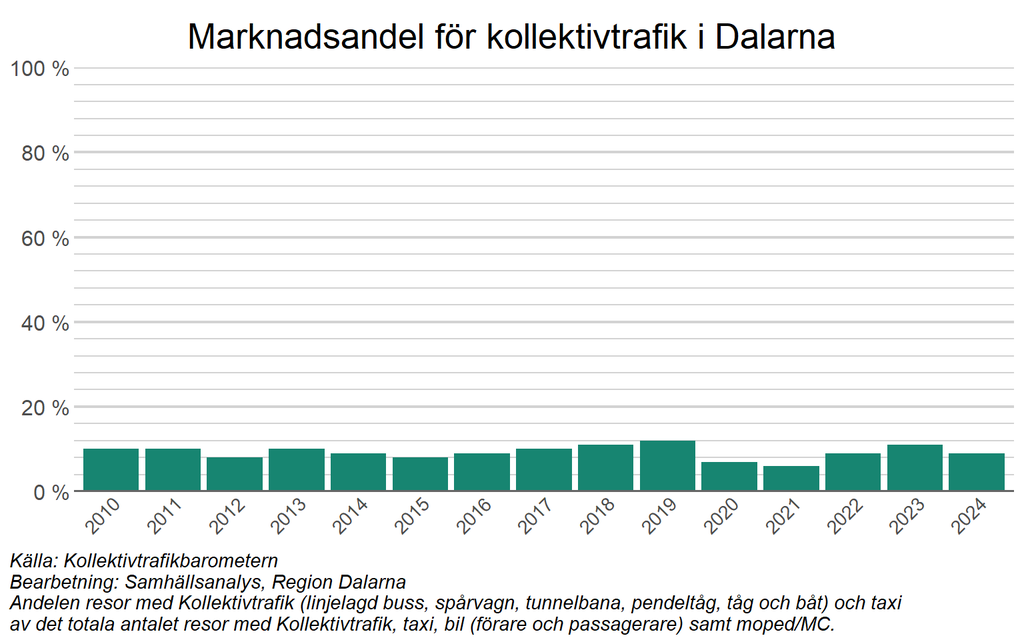

### Elbilar

Andelen personbilar som helt eller delvis drivs av el har ökat tydligt i Dalarna på senare år. Fram till mitten av 2010-talet var andelen mer eller mindre obefintlig, men därefter har ökningen gått snabbt. Initialt ökade framförallt andelen laddhybrider, men på senare år har även andelen rena elbilar ökat kraftigt. Andelen är dock fortfarande relativt låg. År 2024 var ungefär 8 procent av personbilarna i Dalarna antingen rena elbilar eller laddhybrider.

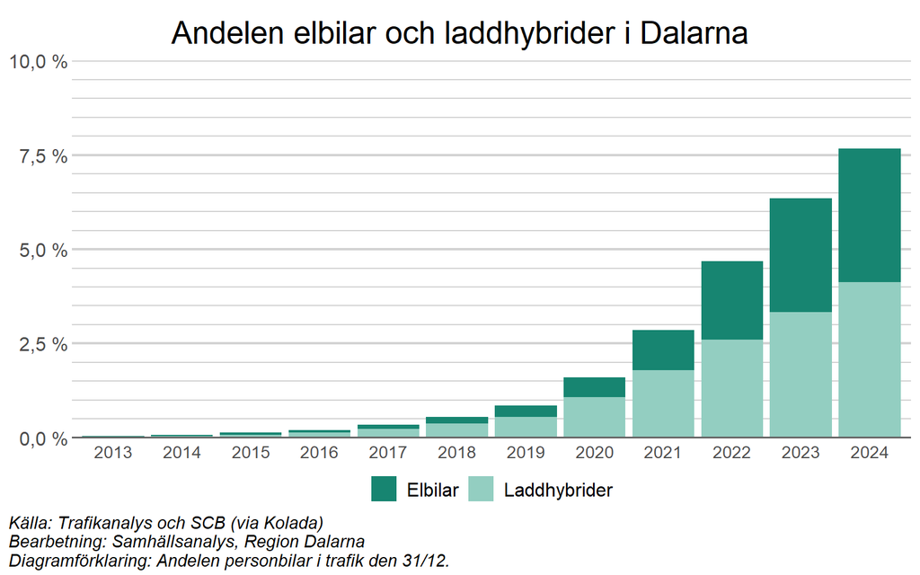

I ett nationellt perspektiv sticker framförallt Stockholms län ut, där mer än var 4:e personbil år 2024 var en ren elbil eller en laddhybrid. Bland övriga län är det framförallt storstadslän som Västra Götaland eller Skåne som har en relativt hög andel elbilar eller laddhybrider (mellan 10 och 15 procent). Lägst andel åtefinns i nordliga län som Norrbotten och Jämtland Härjedalen, men även Gotland har relativt få elbilar.

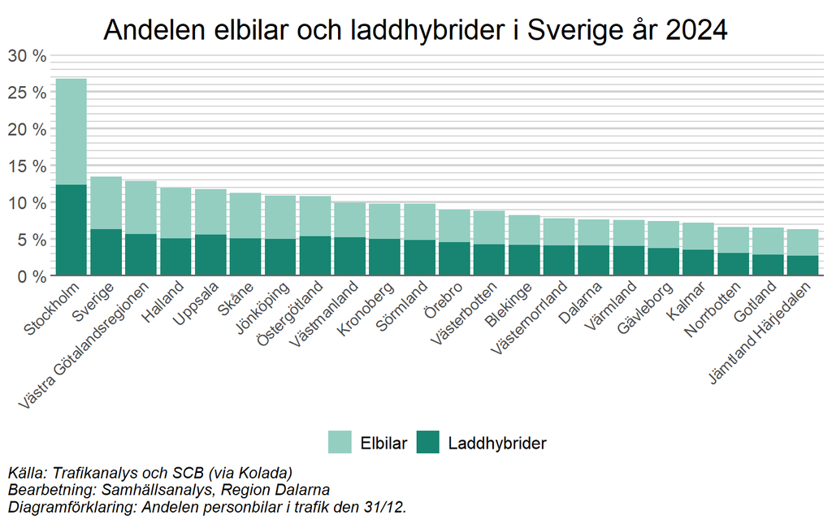

### Avfall

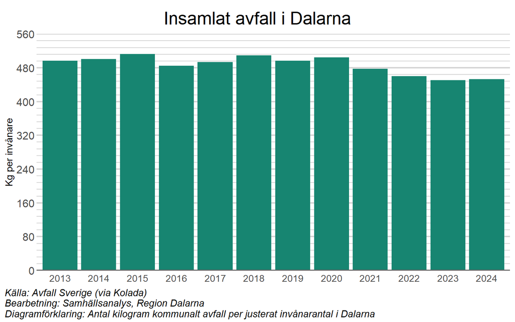

## 1.3 Förnybar elproduktion och ekonomiska värden av energi- och material och råvaror

De ekonomiska aspekterna av ett klimatsmart Dalarna handlar om hur vi tar tillvara naturresurserna och skapar återanvändning och självförsörjning inom planetära gränserna.

Sammanfatting.

Förnybar elproduktion ⬇

Energieffektivitet ⬇

Avfall / BRP ⬇

Självförsörjning av livsmedel och el ⬇

### Förnybar elproduktion

En god tillgång till hållbar energi är avgörande för näringslivets och hela samhällets omställningsförmåga. En ökad regional produktion av förnybar energi bidrar till såväl minskade utsläpp som ökad självförsörjningsförmåga och resiliens för Dalarna. Sveriges samlade energisystem beskrivs utförligt på [Energimyndighetens webbplats](https://www.energimyndigheten.se/energisystemet/sveriges-energisystem/).

Den regionalt producerade energin som omsätts till elektricitet i Dalarna omfattar vatten- och vindkraft samt övrigt, där vatten och vind är de huvudsakliga energikällorna. Det saknas dock statistik över vattenkraft enskilt för vissa år, varför kategorin vattenkraft och övrigt används i diagrammet nedan. I kategorin vattenkraft och övrigt ingår även solkraft som utgör en liten men växande andel över tid. Kategorin har beräknats som skillnaden mellan total elproduktion och elproduktion från vindkraft.

Produktionen av el i Dalarna varierar mellan olika år, bland annat beroende på om det är torrår eller våtår (se exempelvis år 2018 som var ett ovanligt torrt år). I diagrammet visas mängden el producerad av vattenkraft och övrigt respektive vindkraft. Även om vattenkraft och övrigt står för merparten så är trenden tydlig att elproduktionen från vindkraft ökar, och har nästan tredubblats sedan första mätåret 2012. År 2012 gav vindkraften ca 542 500 MVh och år 2023 gav den 1 604 000 MVh. Betydelsen av vindkraft för den totala elproduktionen har därmed också ökat från att ha utgjort ca 11 procent till att år 2023 utgöra knappt 27 procent av den totala produktionen. Efter att ha minskat under 2022, ökade elproduktionen tydligt i Dalarna under 2023, en ökning som helt kan tillskrivas en ökad produktion av vattenkraft och övrigt.

Även elproduktionen från solkraft, som är en del av kategorin vattenkraft och övrigt i diagrammet nedan, har ökat tydligt i Dalarna på senare år, från ungefär 26 900 MVh år 2021 till ca 91 000 MVh år 2023. Trots ökningen stod solkraft bara för 1,5 procent av den totala elproduktionen i Dalarna år 2023.

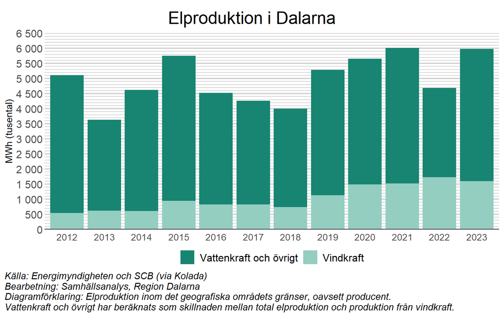

### Energieffektivitet

Ett sätt att mäta den ekonomiska effektiviteten i energianvändningen är att sätta utsläppen som genereras i länet i relation till de ekonomiska värden som produceras med energin. En regions ekonomiska värdeproduktion mäts genom bruttoregionalprodukten (BRP). Energins ekonomiska effektivitet skattas sedan genom att beräkna förädlingsvärdet per ton koldioxidekvivalenter, vilket kopplar ihop utsläppen i länet med den ekonomiska aktiviteten. Att få ut ett större ekonomiskt värde av varje använd energienhet antas innebära en lägre miljöbelastning per producerad krona, och ses därför generellt som positivt.

En viktig frågeställning för tillväxtarbetet är om det är möjligt att ha en fortsatt ökad ekonomisk tillväxt och samtidigt minska energiförbrukningen och utsläppen i samhället, så pass att ekonomisk aktivitet inte orsakar miljöpåverkan. Detta kallas frikoppling och är något som det forskas om. Hittills visar resultaten på exempel där det är möjligt att minska energiproduktionens miljöpåverkan, men ännu inte helt frikoppla den. I forskningen synliggörs även dilemmat med den traditionella tillväxtmodellen som innebär en konstant utvinning av värden från naturresurser utan att hänsyn tas förvaltandet och vårdandet av naturresurser och ekosystemtjänster för att de långsiktigt ska ge en god kontinuerlig avkastning.

Ett ökat förädlingsvärde per mängd förbrukad energi i länet kan betyda att länet har förbättrat energieffektiviteten i de fall industrier och näringar är ungefär desamma mellan mätningarna. En förklaring till en förbättrad energieffektivitet kan annars vara att näringslivets struktur har förändrats i en riktning där energikrävande industrier har lämnat regionen och mer kunskapsintensiv tjänsteproduktion har ökat (som generellt kräver mindre energi). Om energikrävande industrier har lämnat regionen och skapar utsläpp i andra delar av världen är det tyvärr inte självklart att nettoeffekten på de globala utsläppen minskat, då de flesta andra länder har en svagare miljölagstiftning än Sverige.

Mellan 2008 och 2022 ökade energieffektiviteten i ekonomiska termer i Dalarna med ca 108 procent. Förändringen beror framförallt på att utsläppen av växthusgaser i länet har minskat under perioden men även på att BRP för Dalarna har stigit under samma tidsperiod.

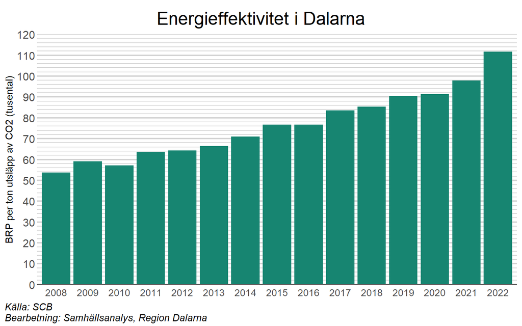

I en nationell jämförelse ligger Dalarnas energieffektivitet på den sämre halvan av intervallet tillsammans med regioner som också är mer glesbefolkade och har tunga industrier.

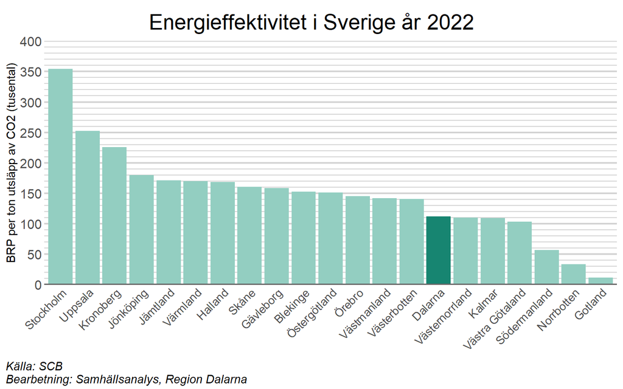

### Avfall/BRP

Ytterligare en indikator på ekonomisk resurseffektivitet är kopplingen mellan mängden insamlat avfall (förbrukade resurser) och den ekonomiska aktiviteten i regionen, mätt genom bruttoregionalprodukten (BRP). Indikatorns värde visar på en positiv trend av att mängden avfall minskar per producerat ekonomiskt värde över perioden från 2013 till 2024. 2013 samlades det in knappt 1 510 kg avfall för varje miljon kronor av Dalarnas BRP under samma år. 2024 hade motsvarande mängd avfall sjunkit till drygt 980 kg avfall. Det kan främst förklaras med att BRP har ökat under perioden.

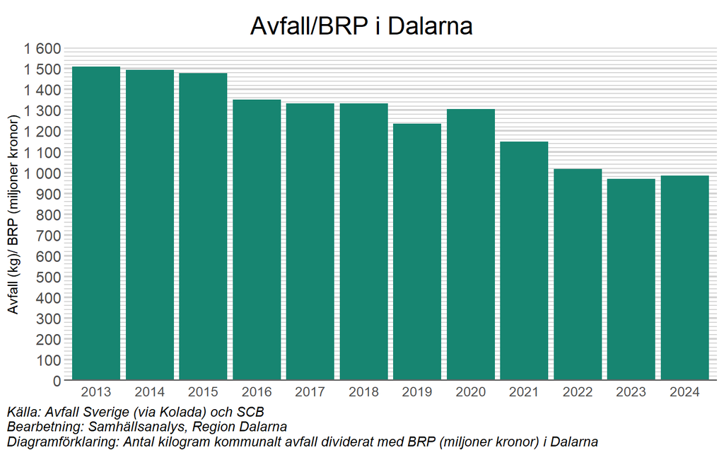

### Självförsörjning mat och el

Klimatförändringarna medför lokalt förändrade mönster för nederbörd, torka och vind men även insekts- och svampangrepp på grödor och skog, höga temperaturer, med mera. Här spelar god samhällsplanering på regional och kommunal nivå en viktig roll. Ett sätt att förbättra beredskapen i Dalarna är att ha en tillräckligt omfattande lokal och hållbar energi- och livsmedelsproduktion. En ökad självförsörjningsgrad är en trygghet på flera sätt och gynnar även miljöns motståndskraft genom en ökad biologisk mångfald.

Diagrammet nedan visar andelen livsmedel inom fem kategorier (fårkött, griskött, matpotatis, mjölkprodukter samt nötkött) som producerats i Dalarna i relation till den mängd livsmedel i varje kategori som konsumerats i länet. Med undantag för matpotatis år 2016, 2019 och 2022, som länet i princip är självförsörjande på, konsumerar befolkningen i Dalarna idag betydligt mer inom samtliga kategorier jämfört med den mängd som produceras i länet. Intressant att notera är dock att självförsörjningsgraden för matpotatis har sjunkit avsevärt de senaste åren, jämfört med åren innan. Detta beror på att skördarna av matpotatis i länet har varit ovanligt små såväl 2023 som 2024 (de lägsta i ton sedan mitten på 00-talet).

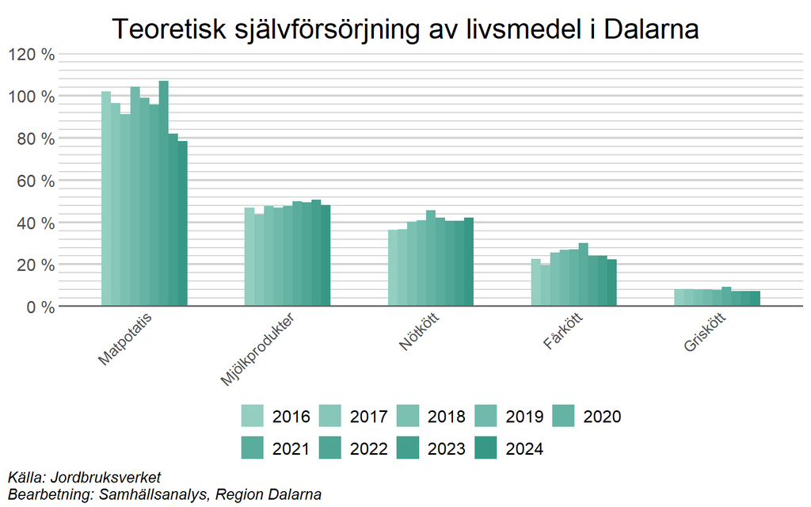

I diagrammet nedan visas en teoretisk beräkning av självförsörjning av elektricitet i Dalarna där den totala elproduktionen i länet visas som andel av den total elförbrukningen. Diagrammet visar en positiv trend för självförsörjningsgraden av elektricitet från 64 procent år 2016 till 118 procent år 2023. Att självförsörjningsgraden ökade tydligt år 2023, då mer el producerades i länet än den som konsumerades, beror i första hand på en låg konsumtion av el, något som potentiellt delvis kan förklaras av Rysslands invasion av Ukraina och dess effekt på elpriserna. Konsumtionen av el var ovanligt låg även 2022, men då var även produktionen av el i länet ovanligt liten (se avsnitt 1.3 ovan).

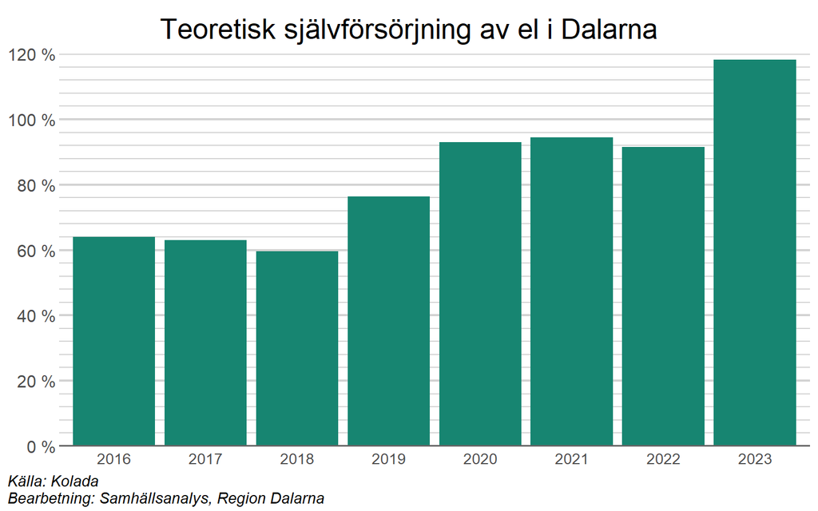

# 2 Ett konkurrenskraftigt Dalarna

I ett konkurrenskraftigt Dalarna är näringslivet livskraftigt och skapar tillväxt inom de planetära gränserna. En väl utvecklad och hållbar infrastruktur skapar värden för näringsliv, boende och besökare. Det är ett Dalarna där allas kunskaper och kompetenser tas till vara och där individer, näringsliv, offentlig sektor och civilsamhälle utvecklas tillsammans och i samspel med omvärlden. Det är också ett nyskapande Dalarna där utmaningsdriven innovation bidrar till ett gott samhälle och hållbar tillväxt.

Den ekonomiska dimensionen av hållbarhet i det regionala utvecklingsarbetet handlar om att använda och hushålla med resurser och förädla idéer på ett miljömässigt och socialt hållbart sätt och ta vara på möjligheterna att därigenom skapa konkurrenskraft och sysselsättning. Med ett cirkulärt system där resurser och värden kan återbrukas främjas en ekonomiskt hållbar utveckling.

I Dalarna finns företag och människor med idéer som kan bidra till att lösa globala problem, och bana väg för goda livsmiljöer och levnadsvillkor för de boende.

## 2.1 Arbetskraften, återväxt och kompetens

Arbetskraftens sysselsättning ⬇

Utbildningsnivåer ⬇

Gymnasieutbildning ⬇

Invandrares arbetsetablering ⬇

Ohälsa ⬇

Återväxt ⬇

### Gymnasieutbildning

Kunskap ger människor möjlighet att växa och påverka sin livssituation. Tillgång till utbildning, kunskap och bildning är avgörande för såväl utvecklingen av samhället, som god välfärd och tillväxt i näringslivet. När arbetsgivare inte hittar rätt kompetens hämmas den ekonomiska utvecklingen. Samtidigt försvagas den sociala hållbarheten när människor ställs utanför arbetsmarknaden. Befolkningens relativt sett låga utbildningsnivåer är en utmaning i stora delar av Dalarna. Ambitionen i Dalastrategin är att fler ska klara en gymnasieexamen för att därmed få bättre förutsättningar att etablera sig på arbetsmarknaden.

Denna indikator mäter andelen elever i Dalarna som har fullföljt en gymnasieutbildning inom fyra år efter att de påbörjat gymnasiet. Sett över hela tidsperioden 2011/12 till 2019/20 finns det en positiv trend, även om andelen fluktuerar mellan åren. Av eleverna som började läsa på gymnasiet i Dalarna läsåret 2011/12 var det 72,6 procent som inom fyra år fullföljde sin utbildning med examen. Den lägsta andelen avklarade examen om 70 procent uppmättes för dem som påbörjade gymnasiet läsåret 2017/18 (möjligen en pandemieffekt), samtidigt som den högsta andelen avklarade examen finns bland de elever som påbörjade gymnasiet läsåret 2019/20, 74,7 procent av dem har tagit ut examen inom fyra år.

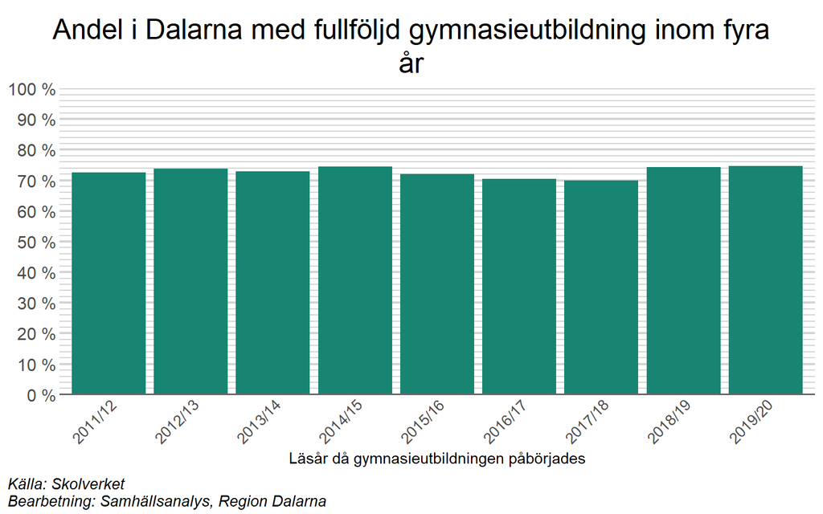

### Invandrares arbetsetablering

Invandring är en del av lösningen för att möta en ökad efterfrågan på arbetskraft och rätt kompetens i Dalarna och Sverige. Dalarna har haft en relativt stor inflyttning av utomeuropeiskt födda under senare år. Många invandrade är i arbetsför ålder och blir därför ett viktigt tillskott till arbetskraften. Denna indikator är ett mått på i vilken takt och utsträckning som invandrade etablerar sig på arbetsmarknaden i Dalarna. Med etablering menas att personen är förvärvsarbetande helt utan stöd från a-kassa eller arbetsmarknadsåtgärd, eller dylikt.

Diagrammet visar tydligt hur andelen etablerade på arbetsmarknaden i arbetsför ålder ökar efter vistelsetid i landet. För det senaste året i perioden, 2024, hade ungefär 47 procent av invandrade med vistelsetid under ett år etablerat sig på arbetsmarknaden. Andelen etablerade på arbetsmarknaden ökar sedan gradvis efter vistelsetid och för samma år var det ca 74 procent i gruppen som vistats i Sverige i tio år eller mer som var etablerade på arbetsmarknaden.

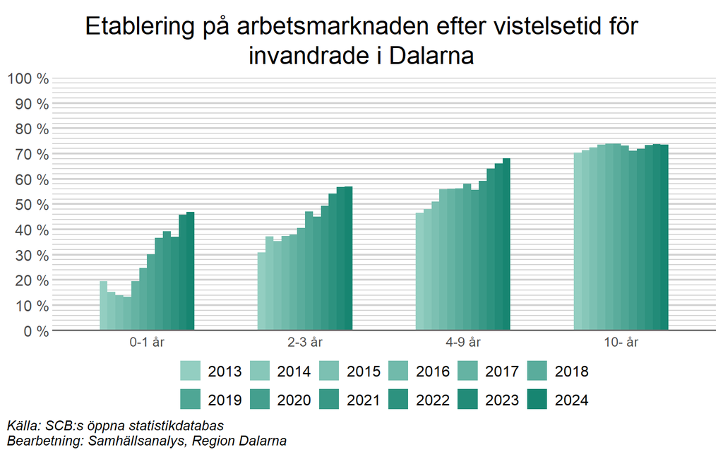

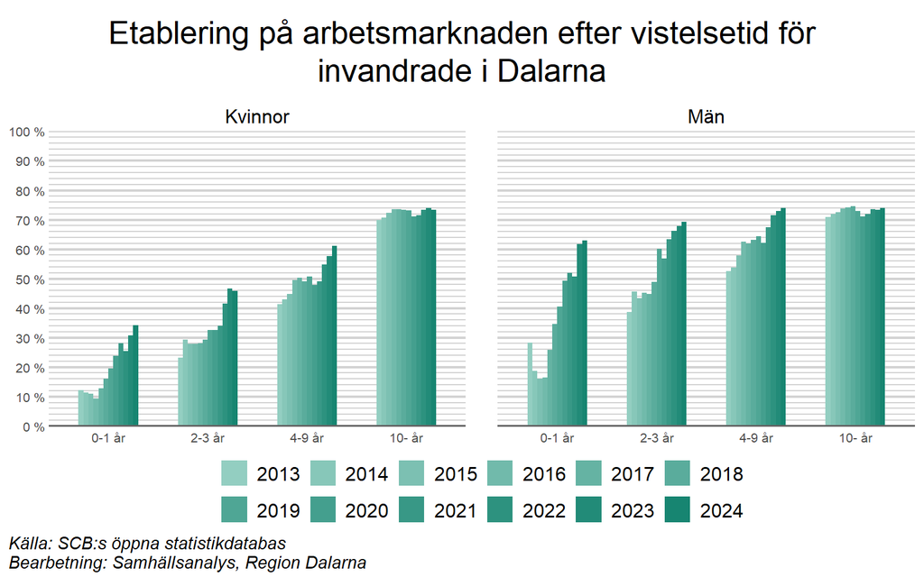

En jämförelse mellan länen när det gäller möjligheten att ha etablerat sig på arbetsmarknaden efter minst 10 år i Sverige visar att Dalarna återfinns i mittensegmentet. Norrbotten har den högsta andelen etablerade med ca 79 procent, och i Södermanland är andelen etablerade efter minst 10 år i landet lägst, med ungefär 72 procent.

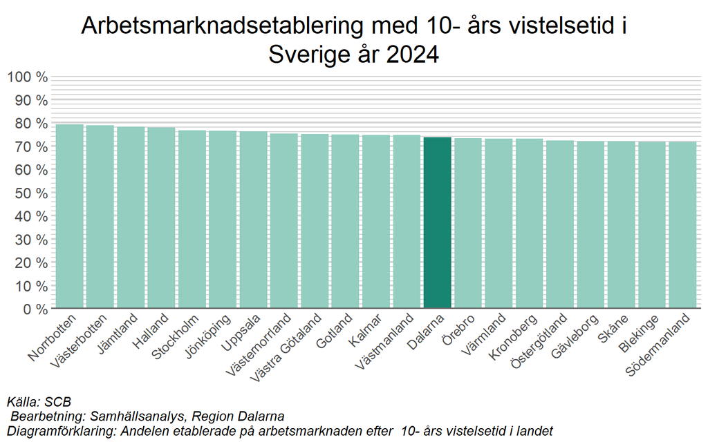

Sjukfrånvaro är kostsamt i form av produktionsbortfall för både arbetsgivare och samhälle, och inte minst för individen.

### Återväxt av befolkningen

**Mer information om statistiken**

Summerad fruktsamhet per kvinna är ett mått på hur många barn som en kvinna i genomsnitt skulle föda under sin fruktsamma period utifrån, den vid tidpunkten för beräkningen, gällande fruktsamheten. I relation till befolkningen var barnafödandet i Sverige år 2024 det lägsta som uppmätts (SCB har data sedan mitten av 1700-talet), en utveckling som är densamma i stora delar av västvärlden (SCB). En viktig förklaring till att barnafödandet har minskat i Sverige under 2010-talet är att sannolikheten att skaffa sitt första barn har minskat. För en fördjupad diskussion runt det låga barnafödandet i Sverige, se rapporten [befolkningsutvecklingen i Dalarna](https://samhallsanalys.regiondalarna.se/befolkningsutveckling)

Fruktsamheten tenderar att variera relativt mycket över tid. Detta kan förklaras med en blandning av faktorer, såsom ekonomiska förhållanden, politiska beslut och kulturella normer. Under 1970-talet sjönk fruktsamheten i Sverige till följd av bland annat en ökad användning av preventivmedel och en ökad andel kvinnor som studerade och arbetade. Under 1980-talet togs diverse politiska beslut med syfte att förbättra fruktsamheten (exempelvis en utökning av antalet dagar i föräldraförsäkringen, se [Försäkringskassan](https://www.forsakringskassan.se/download/18.55c9e2a718ec99c311a46/1713244153025/en-historisk-oversikt-av-foraldrapenning-korta-analyser-2024-2.pdf)), vilket fick en positiv effekt fram till början av 1990-talet, innan en ekonomisk kris fick en tydligt negativ effekt. Under delar av 2000-talet har fruktsamheten varit relativt hög, vilket sannolikt hänger ihop med att den utrikes födda andelen av Sveriges befolkning då ökade (utrikes födda kvinnor har högre fruktsamhet än inrikes födda kvinnor, se [SCB](https://www.scb.se/contentassets/e99a33e517a343488cd1fd73362167c8/be0401_2023i70_br_be51br2302.pdf)).

Fruktsamheten i Dalarna följer i praktiken samma mönster som fruktsamheten i Sverige, men är något högre.

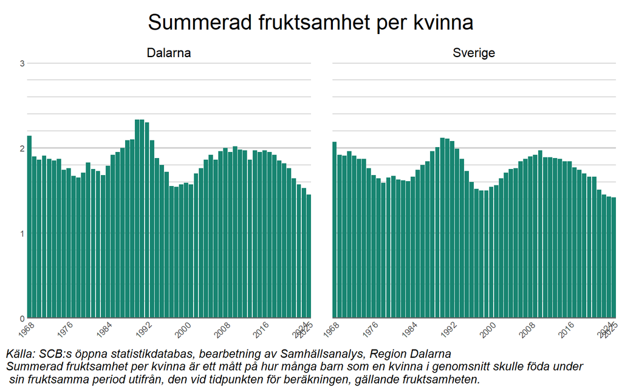

## 2.2 Arbete, företagande och förutsättningar

förutsättningar för arbete och företagande, utfall av företagandet

Företagande ⬇

Infrastrukturförutsättningar ⬇

Jämställdhet ⬇

Brottslighet ⬇

Förtroende för rättsväsendet ⬇

### Företagande

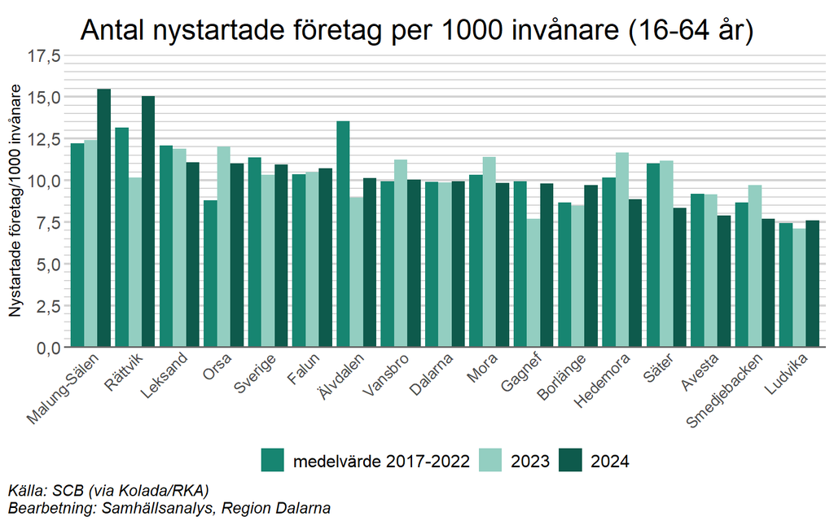

**Största hindren för tillväxt**

### Infrastruktur

**Tillgång till bredband**

Tillgång till en snabb och robust digital infrastruktur är för de flesta en grundförutsättning för att bo och verka i hela Dalarna. Fysiska och digitala mötesplatser gör att vi når både varandra och omvärlden. En av utmaningarna för Dalarna är en ojämnt fördelad digital infrastruktur. Att stärka och tillgängliggöra den digitala infrastrukturen för hela Dalarnas befolkning, oavsett plats, är avgörande för en lyckad digitalisering av samhället.

I Dalarna har andelen av befolkningen med tillgång till, eller möjlighet att ansluta till, bredband om minst 1 Gbit/s ökat från ca 75 procent 2017 till ca 97 procent 2024. Det kan jämföras med riksgenomsnittet som år 2024 var 99 procent.

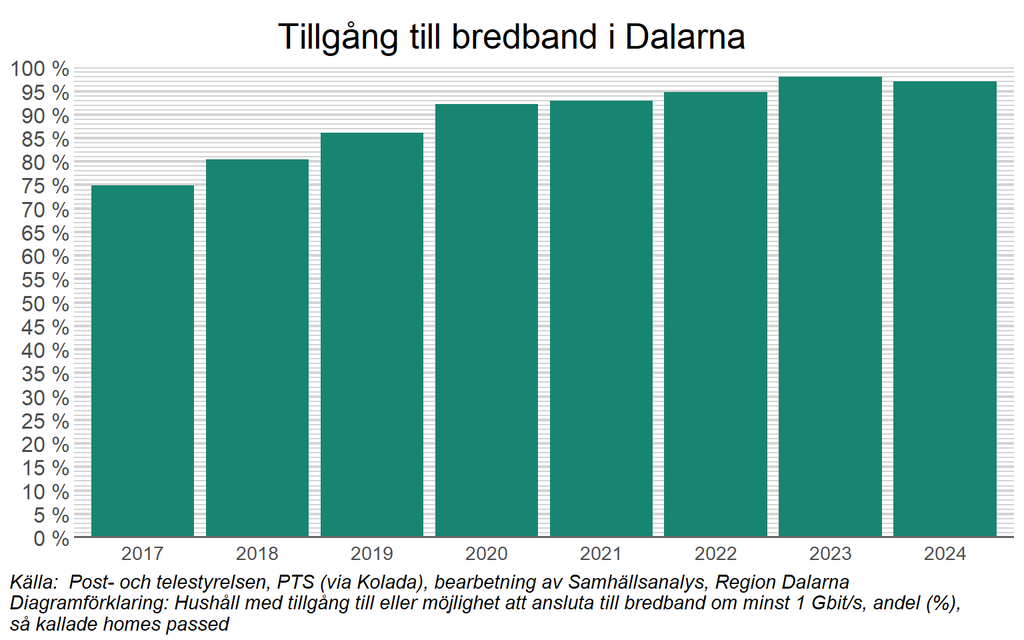

**Tågens punktlighet**

**Annat intressant infrastrukturmått**

### Jämställdhet

Sedan många år har kvinnor och män haft likvärdig tillgång till utbildning och möjlighet att fritt välja yrke. Trots detta består många av könsskillnaderna i arbetslivet.

**Könssegregering i olika branscher**

Många branscher i länet har idag en tydlig övervikt av det ena eller det andra könet, exempelvis byggbranschen som omfattar yrken inom bland annat el och VVS, och där kvinnor bara utgör ungefär 10 procent av de förvärvsarbetande. Även om det har skett en ökning av andelen kvinnor inom byggbranschen är denna ökning ännu liten i sammanhanget. Inom vård och omsorg är bilden densamma men med motsatt könsfördelning. Här utgör kvinnor cirka 77 procent av de förvärvsarbetande.

Att åstadkomma en förändring i närtid av balansen mellan män och kvinnor inom de könssegregerade branscherna förefaller inte vara inom räckhåll då ungdomars studieval fortsätter att vara könsstereotypa.

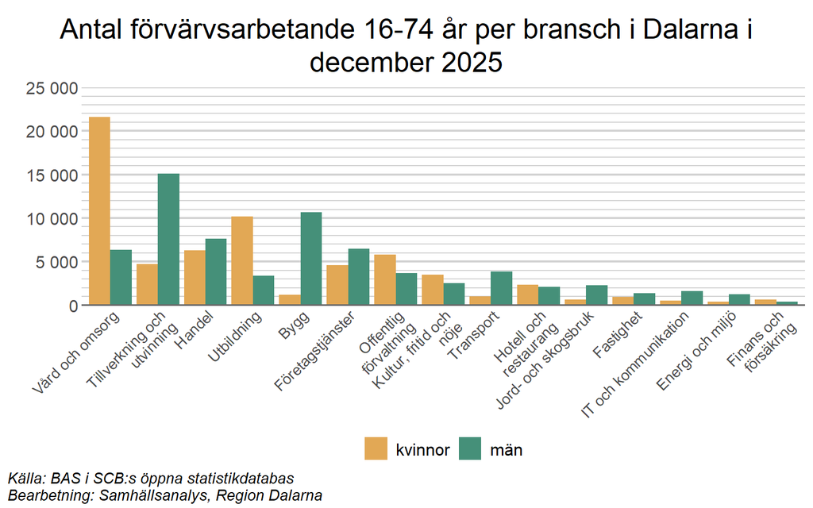

**Föräldrapenning**

Fördelningen av dagar mellan vårdnadshavarna har jämnats ut något sedan slutet av 1990-talet då runt 85-90 procent av föräldrapenningdagarna togs ut av mammorna. Sedan dess har först en (1995), sedan två (2002) och även tre månader (2016) reserverats åt respektive vårdnadshavare (också kallade “pappamånader”). Detta har bidragit till ett jämnare uttag men utvecklingen får ändå sägas gå relativt trögt, då kvinnors andel endast har minskat till runt 69 procent 2025. Svenska vårdnadshavare är således långt ifrån att ge sina barn en jämställd tillgång till sina föräldrar. Skillnaden i uttag påverkar också den disponibla inkomsten, som beskrivits under rubriken Ekonomisk jämställdhet. Skillnaden är som störst mellan sammanboende kvinnor och män när det yngsta barnet är 0–3 år [(Regeringen, 2022)](https://www.regeringen.se/contentassets/46945970585240a4a5bfd9a0f75ecf3d/ekonomisk-jamstalldhet.pdf).

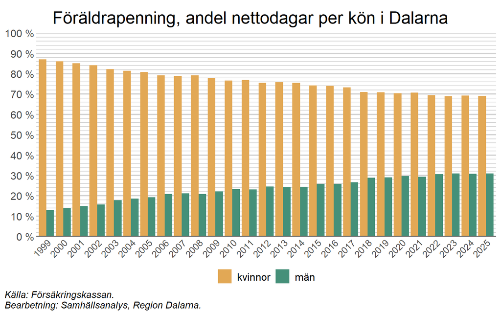

### Brottslighet

**Ekobrottslighet**

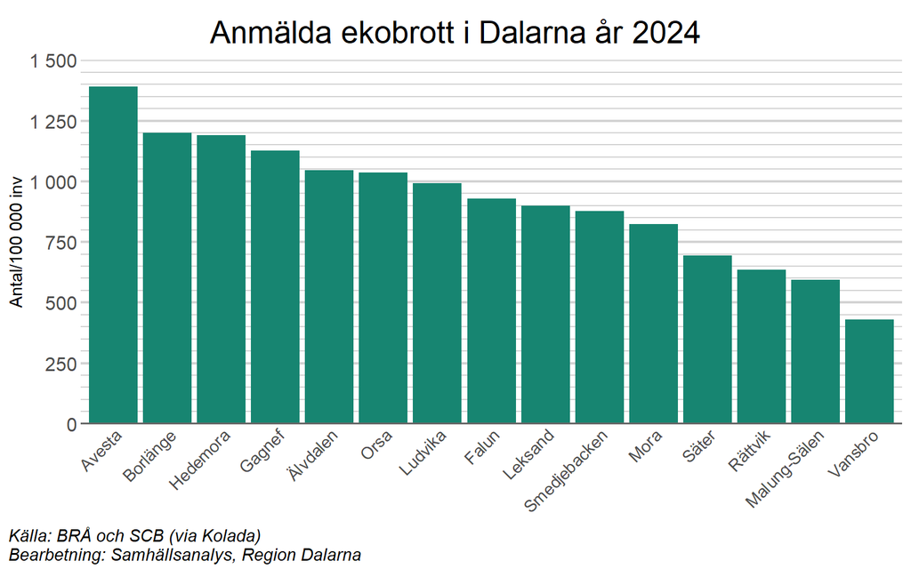

**Bostadsinbrott**

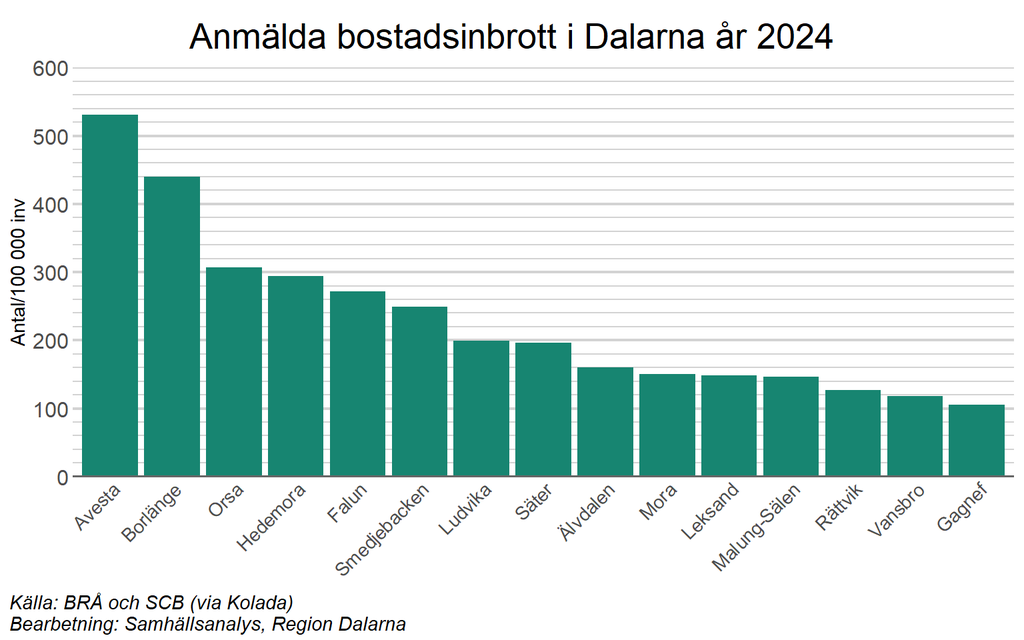

### Förtroende

Förtroendet för rättsväsendet i Dalarna är generellt sett högre för kvinnor än för män, år 2025 svarade ungefär 57 procent av de tillfrågade kvinnorna i Dalarna att de hade mycket stort eller ganska stort förtroende för rättsväsendet, medan motsvarande andel bland männen var ungefär 47 procent. Detta var något lägre än året innan för båda könen, men en ökning jämfört med 2023

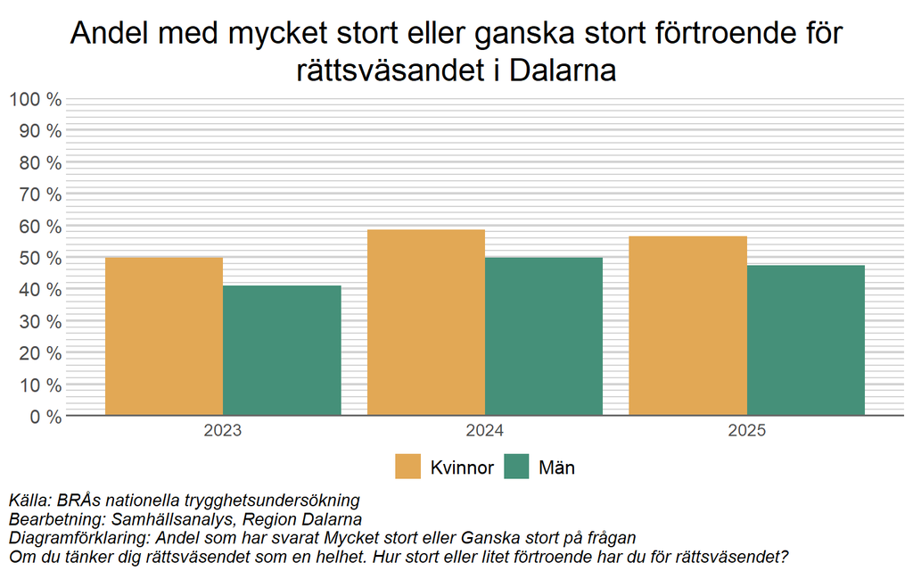

Andelen som svarade att de hade mycket stort eller ganska stort förtroende för rättsväsendet i Dalarna var år 2025 ungefär som genomsnittet bland Sveriges län. Högst förtroende för rättsväsendet har såväl kvinnor som män i Västerbotten (62 procent respektive 63 procent), medan förtroendet är lägst för rättsväsendet i Blekinge (51 procent bland kvinnor och 44 procent bland män)

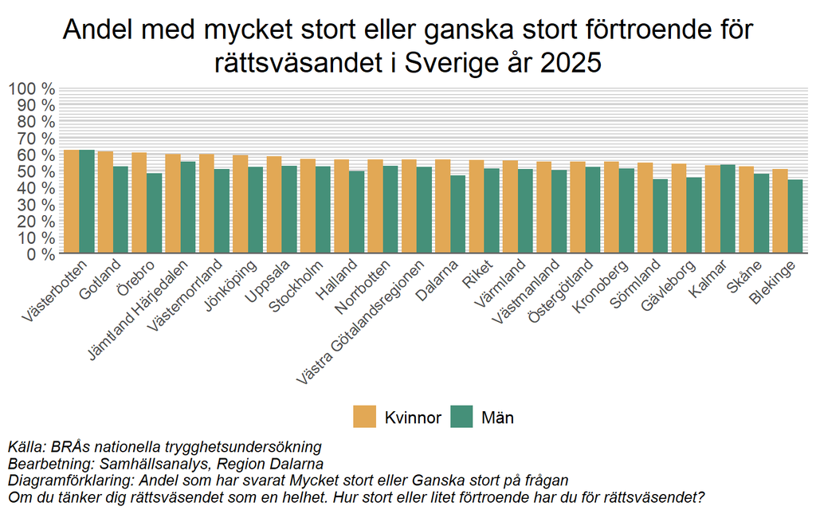

## 2.3 Produktion, produktivitet och export

BRP, arbetsproduktivitet alt. förädlingsvärde ⬇

Löner/ inkomster kvinnor och män ⬇

Regional export ⬇

Ägande, regionalt ägda ftg och utländskt ⬇

### Regional export

Företag med huvudsäte i Dalarna Sysselsatta som arbetar i utlandsägda företag, omsättning arbetsställe per utlandsägt, inhemskt företag.